# The Digital Divide in Santa Clara County

STATS60 Final Project

Steven Luo (sluo04) & Edward Yeung (edwardy)

August 14, 2020

# Introduction

### What is the Digital Divide

According to [this Stanford website](https://cs.stanford.edu/people/eroberts/cs181/projects/digital-divide/start.html): “The idea of the”digital divide" refers to the growing gap between the underprivileged members of society, especially the poor, rural, elderly, and handicapped portion of the population who do not have access to computers or the internet; and the wealthy, middle-class, and young Americans living in urban and suburban areas who have access.” It also names some factors that contribute to the digital divide, including race, income, and education. (this last part is ironic, due to the digital divide in education)

### Project Motivation

With COVID-19 wreaking havoc on the traditions within student education, we’ve seen a shift from in-person to distance learning around the United States and abroad. These challenges have further exposed the inequities between communities within Santa Clara County, and in many cases, school to school.

One problem schools around the country faced was how they could reach students who didn’t have access to technology, which is quite literally the foundation for any distance learning plans to work at all. With classes taking place over a dizzying array of video-conferencing software such as Zoom, Webex, Microsoft Teams, and Google Meet, it’s sometimes easy to forget that students need a working device and internet connection to even begin to participate, with more tools needed for assignments. (printers, scanners, educational software, etc.) Some school districts are loaning out Chromebooks or other devices, but it’s hard to participate in a Zoom lesson, or take advantage of online tutoring without a stable internet connection, or other supporting technology, and not all districts have the capacity to support all of their students.

This “digital divide” makes it harder to learn and for students to succeed in school. Even the brightest minds have trouble adjusting to this fundamental change in the education system — but now consider those who were already falling behind in school. How can we ensure their participation? What about their actual comprehension of the lesson? How do we make sure all students are paying attention, with no teacher at their home to hold them accountable during class? These are just some of the struggles brought about by distance learning, but the consequences of not being able to take part in distance learning are even worse.

### Problem Statement

In this project, we analyzed 2018 Census datasets in order to determine the scope of the educational “digital divide” in Santa Clara County, and make predictions for future implications (specifically looking towards internet and computer accessibility in the age of distance learning), and considering other relevant factors that contribute to this issue, such as household income, coronavirus and its impact, and other variables, which will be covered in the Data Analysis section.

### Related Works

The County Board of Supervisors was presented a report detailing the costs and need for technology in areas around the county, along with recommended actions, partnerships, and funding. You can download the report here: [Santa Clara County Report](http://sccgov.iqm2.com/Citizens/FileOpen.aspx?Type=30&ID=151508) [8 page PDF, 361KB]

These two articles look into the digital divide on a larger scale: [Pew Research Center](https://www.pewresearch.org/fact-tank/2018/10/26/nearly-one-in-five-teens-cant-always-finish-their-homework-because-of-the-digital-divide/), [Public Policy Institute of CA](https://www.ppic.org/blog/how-californias-digital-divide-affects-students/)

Lastly, here is an op-ed a superintendent wrote regarding the impact of COVID-19 on education in the East Side Union High School District, a school district in San Jose that serves over 24,000 students in more than 11 high schools: [Chris Funk, SJ Spotlight](https://sanjosespotlight.com/funk-covid-19-worsens-the-digital-divide-in-san-jose/)

### Background Information

First, what is a census tract? According to the [US Census Bureau](https://www2.census.gov/geo/pdfs/education/CensusTracts.pdf): Census tracts are small, relatively permanent statistical subdivisions of a county. They’re uniquely numbered in each county with a numeric code. Census tracts average about 4,000 inhabitants, with a minimum population of ~1,200 and maximum population of ~8,000.

[Map of Santa Clara County](https://www.sccgov.org/sites/dpd/DocsForms/Documents/SCC_BoundariesMap.pdf)

[Map of Santa Clara County Census Tracts](https://www2.census.gov/geo/maps/dc10map/tract/st06_ca/c06085_santa_clara/DC10CT_C06085_001.pdf)

# Data Analysis

### Obtaining the Data

For this project, we used datasets from the [2014-2018 American Community Survey 5-Year Data Profile](https://www.census.gov/acs/www/data/data-tables-and-tools/data-profiles/), using the filter option to get to the Santa Clara County datasets for the year 2018, which was the most recent year available. We used the [2018 Social Characteristics](https://data.census.gov/cedsci/table?d=ACS%205-Year%20Estimates%20Data%20Profiles&table=DP02&tid=ACSDP5Y2018.DP02&y=2018&g=0400000US06_0500000US06085), [2018 Economic Characteristics](https://data.census.gov/cedsci/table?d=ACS%205-Year%20Estimates%20Data%20Profiles&table=DP03&tid=ACSDP5Y2018.DP03&g=0400000US06_0500000US06085), and [2018 Demographic Characteristics](https://data.census.gov/cedsci/table?g=0400000US06_0500000US06085&d=ACS%205-Year%20Estimates%20Data%20Profiles&tid=ACSDP5Y2018.DP05) options, then used the “Customize Table” feature to add a geography to each of the tables, or “All Census Tracts Within Santa Clara County”, and downloaded each of those sets. This left us with .csv files with hundreds of rows (each row represents a unique census tract within Santa Clara County) and columns (each column represents a different variable within the dataset).

For coronavirus data in Santa Clara County, we looked at [California’s Open Data Portal](https://data.ca.gov/dataset/covid-19-cases) and downloaded the .csv file from there on August 1, 2020 (the data spans the period beginning March 18, 2020 to July 31, 2020). From there, we only looked at the section of the dataset with a row label of Santa Clara County.

### Data Wrangling and Cleaning

```r
# Loading packages
library(ggplot2)
library(utils)
library(plyr)
library(stringr)
library(readxl)

# Setting workspace to specific folder with all files
setwd("~/Desktop/stats60finalproject/")
```

Santa Clara Census Tract Map: https://www2.census.gov/geo/maps/dc10map/tract/st06_ca/c06085_santa_clara/DC10CT_C06085_001.pdf

### General Approach

(For a more detailed walkthrough, please read the comments in each code chunk.) First, we load all libraries needed for our data wrangling and cleaning. Next, we read in the file (usually .csv) and store it in a new variable. We then delete the non-numeric first row, and readjust row numbers to match. This is because each row corresponds to a unique census tract, so the first row in any of the resulting variables will all represent data from the same census tract (you can check the census tract in the “censustracts” variable in the global environment.

Then, we used the key (downloaded with the data, see project folder) in order to rename the appropriate columns, since the variable we read the file data into has a lot of extraneous data and variables that we will not be using. We use the key to determine which columns contain the variable and data of interest, and create a new variable storing just these variables. Next, we rename the columns for readability and ease of access, and change numerical data to numeric type, as appropriate. For some of these files, additional processing specific to that file was necessary, and you can see the details in the code chunks below. For example, for computer and internet access, we did additional calculations to determine the percentage of the total population with computer and internet access, respectively, and stored them in new columns.

In order to use the coronavirus data, we first read the file, delete the unnecessary rows and columns so only Santa Clara County data remains, and it is ready for visualizations!

#### School Enrollment, Computer and Internet Use

Data wrangling and cleaning for the “censusdatasocial.csv” file:

```r
# Reading the csv file into R
censusdatasocial <- read.csv("censusdatasocial.csv")

# Deleting the non-numeric first, second to last, and last row
censusdatasocial <- censusdatasocial[-c(1, 374, 375), ]

# Adjusting row numbers
rownames(censusdatasocial) <- NULL
```

Key: “NAME”: Geographic Area Name

“DP02_0001E”: Estimate!!HOUSEHOLDS BY TYPE!!Total households

“DP02_0054E”: Estimate!!SCHOOL ENROLLMENT!!Population 3 years and over enrolled in school!!Kindergarten

“DP02_0055E”: Estimate!!SCHOOL ENROLLMENT!!Population 3 years and over enrolled in school!!Elementary school (grades 1-8)

“DP02_0056E”: Estimate!!SCHOOL ENROLLMENT!!Population 3 years and over enrolled in school!!High school (grades 9-12)

```r
# Use column names to pull relevant data, use the provided key.

# Creates dataframe storing census tract names, because formatting between
# Census datasets are the same, we only need to do this once.
censustracts <- censusdatasocial[c("NAME")]

# Creates dataframe storing households per census tract
households <- censusdatasocial[c("DP02_0001E")]

# Creates dataframe storing number of people over the age of 3 and
# enrolled in school, including kindergarten, elementary & middle (grades 1-8),
# high (grades 9-12), and college/graduate school. Excluded preschool and
# nursery school as technology need is negligible.
schoolaged <- censusdatasocial[c("DP02_0054E", "DP02_0055E", "DP02_0056E", "DP02_0057E")]

# Renaming columns (written for Mac, may need to reorder names on Windows)
censustracts <- rename(censustracts, c("NAME"="census_tract_names"))
households <- rename(households, c("DP02_0001E"="total_households"))
schoolaged <- rename(schoolaged, c("DP02_0054E"="kindergarten", "DP02_0055E"="elem_middle", "DP02_0056E"="high", "DP02_0057E"="college_grad"))

# Changing data to numeric type
households$total_households <- as.numeric(households$total_households)
schoolaged$kindergarten <- as.numeric(schoolaged$kindergarten)
schoolaged$elem_middle <- as.numeric(schoolaged$elem_middle)
schoolaged$high <- as.numeric(schoolaged$high)
schoolaged$college_grad <- as.numeric(schoolaged$college_grad)

# New dataframe storing total number of students in each census tract and
# changing the column name.
totalstudents <- data.frame(rowSums(schoolaged))
totalstudents <- rename(totalstudents, c("rowSums.schoolaged."="total_students"))

# Shortening Census Tract names to number only
for (i in 1:length(censustracts$census_tract_names)) {
  censustracts$census_tract_names[i] <- str_remove(censustracts$census_tract_names[i], pattern="Census Tract ")
  censustracts$census_tract_names[i] <- str_remove(censustracts$census_tract_names[i], pattern=", Santa Clara County, California")
}
```

#### Household Income

Data wrangling and cleaning for the “censusdataeconomic.csv” file:

```r
# Reading the csv file into R
censusdataeconomic <- read.csv("censusdataeconomic.csv")

# Deleting the non-numeric first row
censusdataeconomic <- censusdataeconomic[-c(1, 374, 375), ]

# Adjusting row numbers
rownames(censusdataeconomic) <- NULL
```

Key: “DP03_0062E”: Estimate!!INCOME AND BENEFITS (IN 2018 INFLATION-ADJUSTED DOLLARS)!!Total households!!Median household income (dollars)

“DP03_0063E”: Estimate!!INCOME AND BENEFITS (IN 2018 INFLATION-ADJUSTED DOLLARS)!!Total households!!Mean household income (dollars)

```r
# Use column names to pull relevant data, use the provided key.

# Creates dataframe storing mean and median household income within each
# Census tract.
householdincome <- censusdataeconomic[c("DP03_0062E", "DP03_0063E")]

# Renaming columns
householdincome <- rename(householdincome, c("DP03_0062E"="median_household_income", "DP03_0063E"="mean_household_income"))

# Because households with income >= $250,000/year are stored as $250,000+ in the median column, we need to remove the "+" before turning them into numeric values. Values of 250000 in median_household_income will represent households making greater than or equal to $250,000. This is the only exception, so code doesn't need to be general.
for (i in 1:length(householdincome$median_household_income)) {
  if (householdincome$median_household_income[i] =="250,000+")
    householdincome$median_household_income[i] = "250000"
}

# Changing data to numeric type
householdincome$median_household_income <- as.numeric(householdincome$median_household_income)
householdincome$mean_household_income <- as.numeric(householdincome$mean_household_income)
```

Important note: Values of 250000 in median_household_income will represent households making greater than or equal to $250,000, because households with income ≥ $250,000/year are stored as $250,000+ in the median column.

#### Ethnicity/Race

Data wrangling and cleaning for the “censusdatademographic.csv” file:

```r
# Reading the csv file into R
censusdatademographic <- read.csv("censusdatademographic.csv")

# Deleting the non-numeric first row
censusdatademographic <- censusdatademographic[-c(1, 374, 375), ]

# Adjusting row numbers
rownames(censusdatademographic) <- NULL

# Pulling out all necessary columns
demographicethnicity <- censusdatademographic[c("DP05_0070E","DP05_0071E", "DP05_0077E", "DP05_0078E", "DP05_0079E", "DP05_0080E" ,"DP05_0081E", "DP05_0082E", "DP05_0083E")]

# Renaming columns
demographicethnicity <- rename(demographicethnicity, c("DP05_0070E"='total_population', "DP05_0071E" = 'hispanic_or_latino_of_any_race', "DP05_0077E" = 'white_alone', "DP05_0078E" = 'black_or_african_american_alone', "DP05_0079E" = 'american_indian_and_alaska_native_alone',  "DP05_0080E" = 'asian_alone',  "DP05_0081E"='native_hawaiian_and_other_pacific_islander_alone', "DP05_0082E"='some_other_race_alone',  "DP05_0083E"='two_or_more_races'))

# Converting all columns to of type double and creating percentage dataframe
# utilizing operations between variables
d <- demographicethnicity

d$hispanic_latino_percentoftotal <- as.numeric(d$`hispanic_or_latino_of_any_race`)/as.numeric(d$`total_population`)

d$white_percentoftotal <- as.numeric(d$`white_alone`)/as.numeric(d$`total_population`)

d$black_or_african_american_percentoftotal <- as.numeric(d$`black_or_african_american_alone`)/as.numeric(d$`total_population`)

d$american_indian_and_alaska_native_percentoftotal <- as.numeric(d$`american_indian_and_alaska_native_alone`)/as.numeric(d$`total_population`)

d$asian_alone_percentoftotal <- as.numeric(d$`asian_alone`)/as.numeric(d$`total_population`)

d$native_hawaiian_and_other_pacific_islander_percentoftotal <- as.numeric(d$`native_hawaiian_and_other_pacific_islander_alone`)/as.numeric(d$`total_population`)

d$some_other_race_percentoftotal <- as.numeric(d$`some_other_race_alone`)/as.numeric(d$`total_population`)

d$two_or_more_races_percentoftotal <- as.numeric(d$`two_or_more_races`)/as.numeric(d$`total_population`)

# Inputting the dataframe into a new dataframe by pulling out the necessary columns
demographicpercentage <- d[c(10,11,12,13,14,15,16,17)]
```

#### Household and Technology/Internet Access

Continuation of data wrangling and cleaning for the “censusdatasocial.csv” file:

```r
# Pulling out all necessary columns
techaccess <- censusdatasocial[c("DP02_0151E", "DP02_0152E")]

# Renaming columns
techaccess <- rename(techaccess, c("DP02_0151E"='computer_totalhouseholds', "DP02_0152E"='internet_totalhouseholds'))

# Converting all columns to type double

techaccess$computer_totalhouseholds <- as.numeric(techaccess$`computer_totalhouseholds`)

techaccess$internet_totalhouseholds <- as.numeric(techaccess$`internet_totalhouseholds`)

# Creating percentage dataframe
techacesspercentage <- techaccess;

techacesspercentage$computer_percentoftotal <- as.numeric(techacesspercentage$`computer_totalhouseholds`)/as.numeric(households$'total_households')

techacesspercentage$internet_percentoftotal <- as.numeric(techacesspercentage$`internet_totalhouseholds`)/as.numeric(households$'total_households')

# Extracting needed columns
techacesspercentage <- techacesspercentage[c(3,4)]
```

Now putting it all together into one dataframe:

```r
census_df <- data.frame(censustracts, households, schoolaged, totalstudents, householdincome, demographicethnicity, demographicpercentage, techacesspercentage, techaccess)
```

Processing the coronavirus data (“coronadata.csv”):

```r
# Reading the csv file into R
CoronaData <- read.csv("CoronaData.csv")

# Deleting unnecessary rows
CoronaData <-  CoronaData[CoronaData$county == "Santa Clara",]

# Deleting unnecessary columns
CoronaData = subset(CoronaData, select = -c(totalcountdeaths,newcountconfirmed,newcountdeaths))

# Optimizing the date values in the date column
CoronaData$date <- gsub("T00:00:00", "", CoronaData$date)
```

### About the Variables

After running all code chunks, we get these variables:

1. census_df: This is a dataframe that combines all the relevant variables we pulled from the Census data files.
2. censusdatademographic: This is a variable that stores all data from the “censusdatademographic.csv” file.
3. censusdataeconomic: This is a variable that stores all data from the “censusdataeconomic.csv” file.
4. censusdatasocial: This is a variable that stores all data from the “censusdatasocial.csv” file.
5. censustracts: This stores the names of each census tract. Each row represents the name of a different census tract.
6. computer_to_income: This variable stores the relevant data for a later visualization.
7. computer_to_internet: This variable stores the relevant data for a later visualization.
8. CoronaData: This stores all data from the “CoronaData.csv” file.
9. d: This is a variable used for processing the demographics data.
10. demographicethnicity: This variable stores the population of each census tract by ethnic/racial group.
11. demographicpercentage: This variable stores the percent of the population of each census tract by ethnic/racial group.
12. householdincome: This variable stores the median and mean household income by census tract.
13. households: This variable stores the total number of households in each census tract.
14. income_minority_populations: This variable stores the relevant data for a later visualization.
15. internet_to_income: This variable stores the relevant data for a later visualization.
16. internet_to_minority: This variable stores the relevant data for a later visualization.
17. schoolaged: This variable stores the number of school-aged children in each census tract, broken down into kindergarten, elementary-middle, high, and college students.
18. techaccess: This variable stores the relevant data for a later visualization.
19. techaccesspercentage: This variable stores the relevant data for a later visualization.
20. totalstudents: This variable stores the number of school-aged children in each census tract.

Most variables will have 372 rows, because there are 372 census tracts. It’s amazing how we were able to trim down the data from the original file, with hundreds of rows, and even more columns, down to usuable variables of a much more manageable size!

# Data Analysis and Visualization

## Single Variable Visualizations

Note: these graphs are provided for context only. By looking at these bar charts, you can get a sense of the demographics and distribution of different variables in different census tracts. For detailed comparisons and more accurate visualizations, look to the next section. Census tract names on the x-axis are ordered numerically, so the tract name on the left would be smaller than a tract name on the right. For exact names, refer to the data.

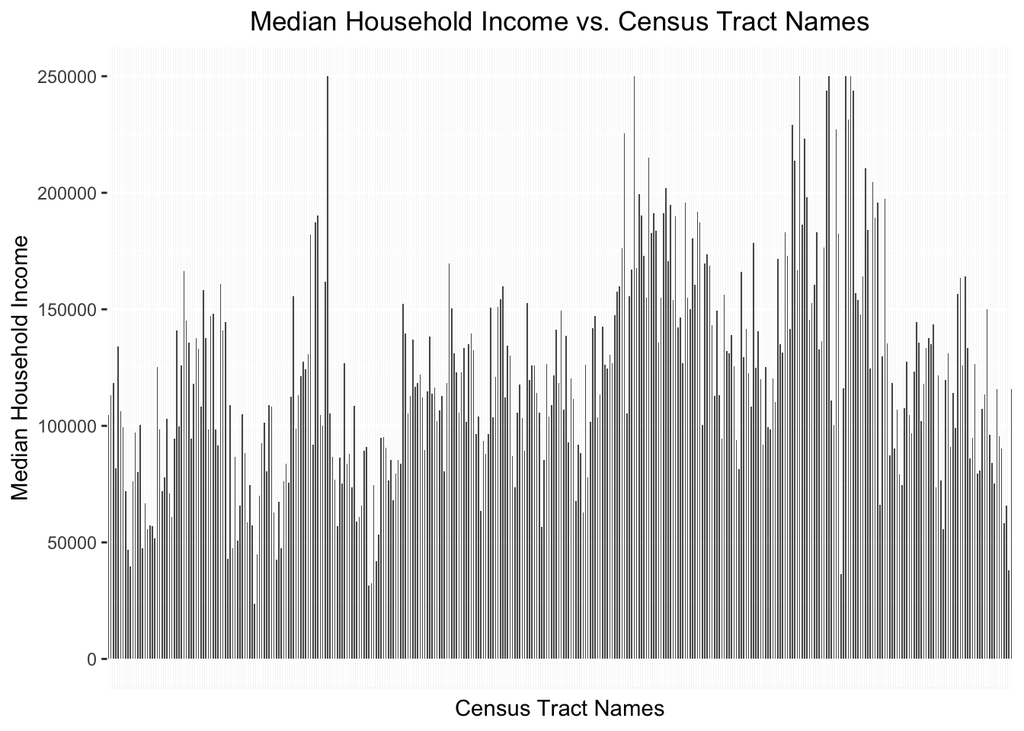

```r
# Bar chart of Median Income v Census Tract Names
# Data wrangling
median_tractnames <- censustracts[c("census_tract_names")]
median_tractnames["median_household_income"] <- householdincome["median_household_income"]

# Plotting the graph
ggplot(data=median_tractnames, aes(x=census_tract_names, y=median_household_income)) +
  ggtitle("Median Household Income vs. Census Tract Names")+
  geom_bar(stat="identity",width=0.5)+
  theme(plot.title = element_text(hjust = 0.5))+
  xlab("Census Tract Names")+
  ylab("Median Household Income")+
  theme(axis.text.x = element_blank(), axis.ticks.x = element_blank())
```

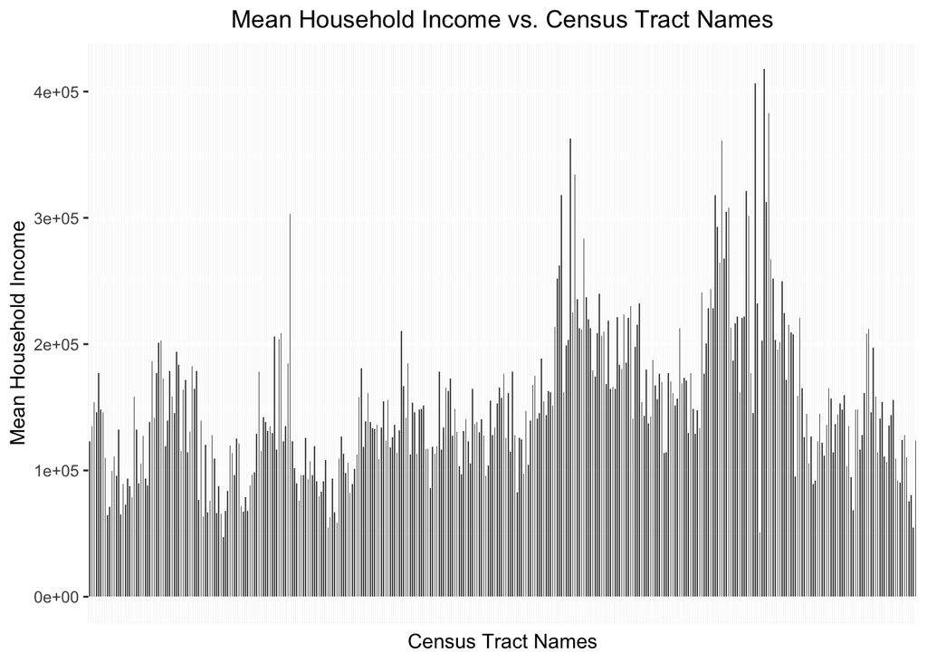

```r
# Bar chart of Mean Income v Census Tract Names
# Data wrangling
mean_tractnames <- censustracts[c("census_tract_names")]
mean_tractnames["mean_household_income"] <- householdincome["mean_household_income"]

# Plotting the graph
ggplot(data=mean_tractnames, aes(x=census_tract_names, y=mean_household_income)) +
  ggtitle("Mean Household Income vs. Census Tract Names")+
  geom_bar(stat="identity",width=0.5)+
  theme(plot.title = element_text(hjust = 0.5))+
  xlab("Census Tract Names")+
  ylab("Mean Household Income")+
  theme(axis.text.x = element_blank(), axis.ticks.x = element_blank())
```

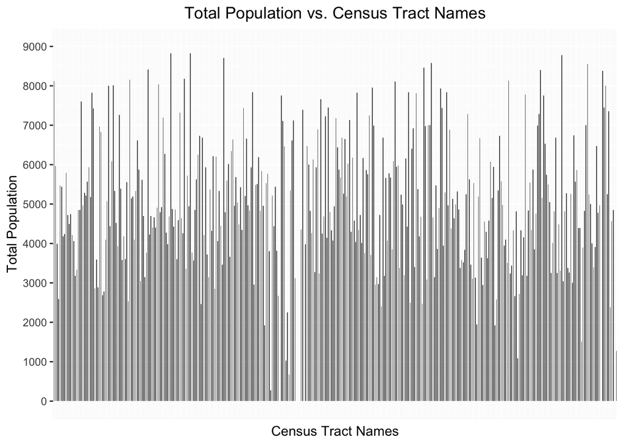

```r
# Bar chart of Population v Census Tract Names
# Data wrangling
population_tractnames <- censustracts[c("census_tract_names")]
population_tractnames$total_population <- as.numeric(demographicethnicity$total_population)
# population_tractnames

# Plotting the graph
ggplot(data=population_tractnames, aes(x=census_tract_names, y=total_population)) +
  ggtitle("Total Population vs. Census Tract Names")+
  geom_bar(stat="identity",width=0.5)+
  theme(plot.title = element_text(hjust = 0.5))+
  xlab("Census Tract Names")+
  ylab("Total Population")+
  scale_y_continuous(breaks = seq(0, 9000, by=1000), limits=c(0,9000))+
  theme(axis.text.x = element_blank(), axis.ticks.x = element_blank())
```

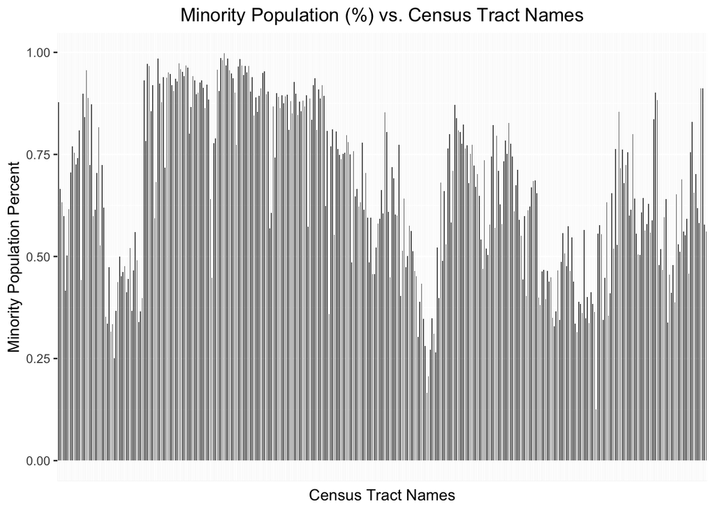

```r
# Bar chart of Minority Population v Census Tract Names

# Data wrangling
minoritypopulation_tractnames <- censustracts[c("census_tract_names")]

minoritypopulation_tractnames$minorityPercentage <- as.numeric(demographicpercentage$`hispanic_latino_percentoftotal`)+as.numeric(demographicpercentage$`black_or_african_american_percentoftotal`)+as.numeric(demographicpercentage$`american_indian_and_alaska_native_percentoftotal`)+as.numeric(demographicpercentage$`asian_alone_percentoftotal`)+as.numeric(demographicpercentage$`native_hawaiian_and_other_pacific_islander_percentoftotal`)+as.numeric(demographicpercentage$`some_other_race_percentoftotal`)+as.numeric(demographicpercentage$`two_or_more_races_percentoftotal`)

# Plotting the graph
ggplot(data=minoritypopulation_tractnames, aes(x=census_tract_names, y=minorityPercentage)) +
  ggtitle("Minority Population (%) vs. Census Tract Names")+
  geom_bar(stat="identity",width=0.5)+
  theme(plot.title = element_text(hjust = 0.5))+
  xlab("Census Tract Names")+
  ylab("Minority Population Percent")+
  theme(axis.text.x = element_blank(), axis.ticks.x = element_blank())
```

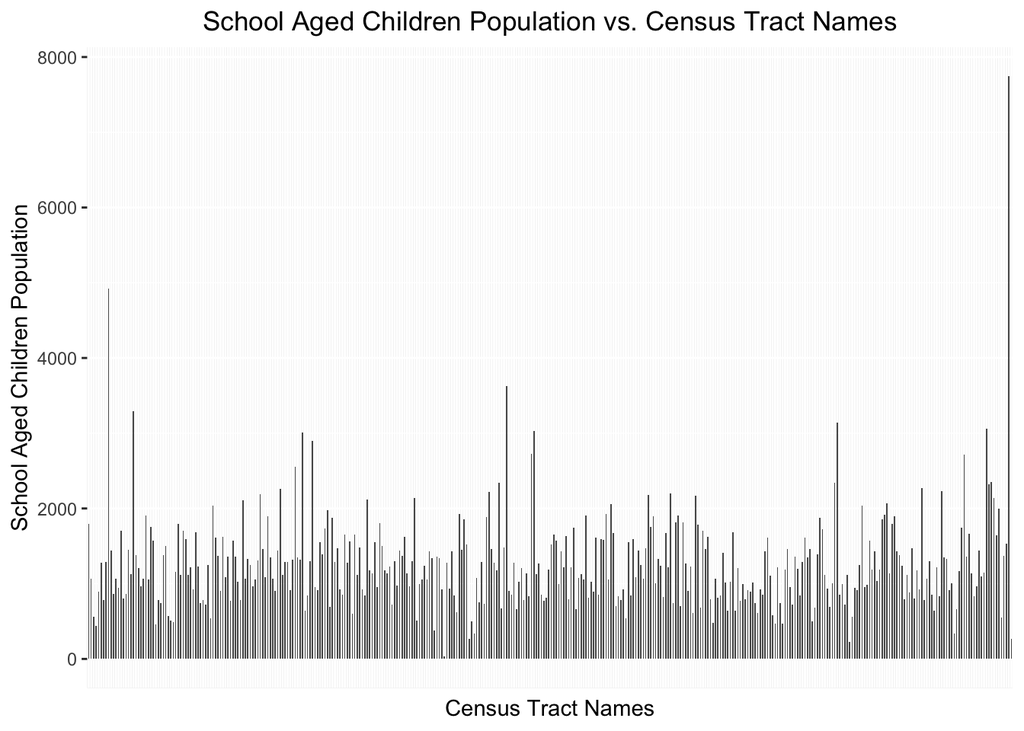

```r
# Bar chartt of School Aged Children v Census Tract Names
# Data wrangling
schoolaged_tractnames <- censustracts[c("census_tract_names")]
schoolaged_tractnames["total_students"] <- totalstudents["total_students"]

# Plotting the graph
ggplot(data=schoolaged_tractnames, aes(x=census_tract_names, y=total_students)) +
  ggtitle("School Aged Children Population vs. Census Tract Names")+
  geom_bar(stat="identity",width=0.5)+
  theme(plot.title = element_text(hjust = 0.5))+
  xlab("Census Tract Names")+
  ylab("School Aged Children Population")+
  theme(axis.text.x = element_blank(), axis.ticks.x = element_blank())
```

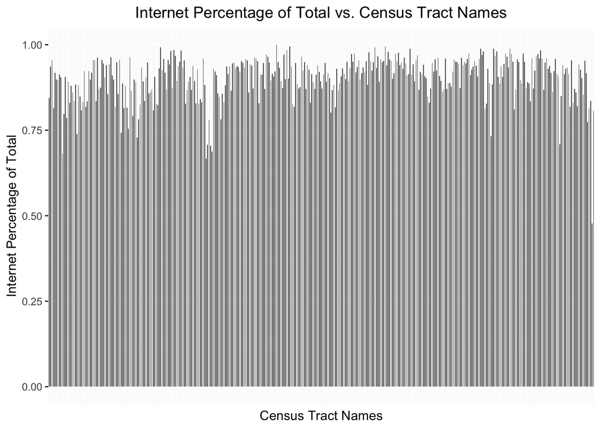

```r
# Bar chart of Internet Access v Census Tract Names
# Data wrangling
internetaccess_tractnames <- censustracts[c("census_tract_names")]
internetaccess_tractnames["internet_percentoftotal"] <- techacesspercentage["internet_percentoftotal"]

# Plotting the graph
ggplot(data=internetaccess_tractnames, aes(x=census_tract_names, y=internet_percentoftotal)) +
  ggtitle("Internet Percentage of Total vs. Census Tract Names")+
  geom_bar(stat="identity",width=0.5)+
  theme(plot.title = element_text(hjust = 0.5))+
  xlab("Census Tract Names")+
  ylab("Internet Percentage of Total")+
  theme(axis.text.x = element_blank(), axis.ticks.x = element_blank())
```

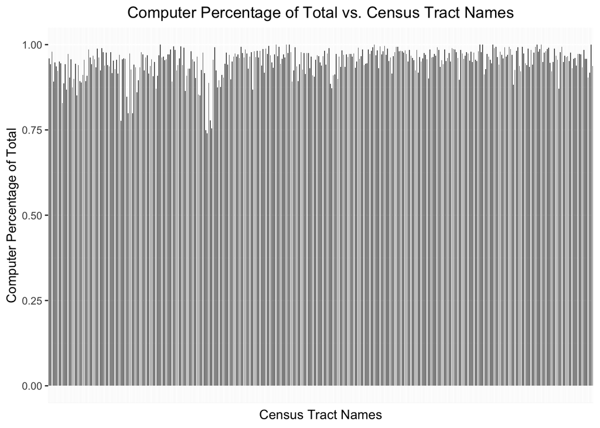

```r
# Bar chart of Computer Access v Census Tract Names
# Data wrangling
computeraccess_tractnames <- censustracts[c("census_tract_names")]
computeraccess_tractnames["computer_percentoftotal"] <- techacesspercentage["computer_percentoftotal"]

# Plotting the graph
ggplot(data=computeraccess_tractnames, aes(x=census_tract_names, y=computer_percentoftotal)) +
  ggtitle("Computer Percentage of Total vs. Census Tract Names")+
  geom_bar(stat="identity",width=0.5)+
  theme(plot.title = element_text(hjust = 0.5))+
  xlab("Census Tract Names")+
  ylab("Computer Percentage of Total")+
  theme(axis.text.x = element_blank(), axis.ticks.x = element_blank())
```

## Multivariable Comparisons & Analyses

#### Median Household Income vs. Internet Access Visualization

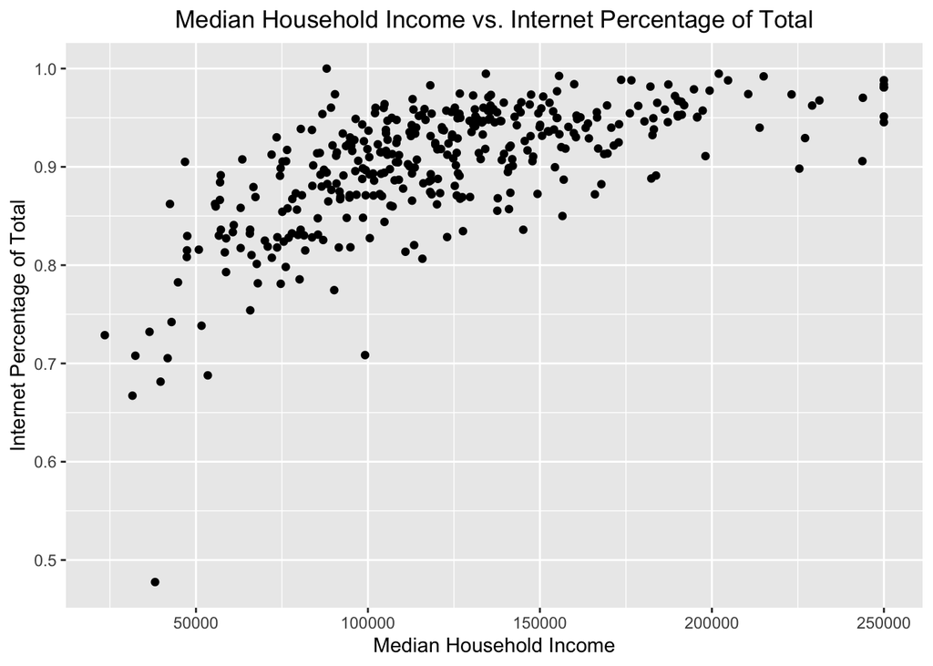

```r
# ScatterPlot of Internet Access v Income

# Data wrangling

internet_to_income <- techacesspercentage[c("internet_percentoftotal")]

internet_to_income["median_household_income"] <- householdincome["median_household_income"]

# Plotting the graph

ggplot(internet_to_income, aes(x = median_household_income, y = internet_percentoftotal)) +
  ggtitle("Median Household Income vs. Internet Percentage of Total") +
  theme(plot.title = element_text(hjust = 0.5)) +
  xlab("Median Household Income") +
  ylab("Internet Percentage of Total") +
  geom_point()
```

This program plots the median household income against the percentage of the households within each census tract with internet access in the form of a scatterplot. Each point represents a different census tract. Again, there are several points stacked vertically at $250,000 due to the way the data was stored. We define access to the internet as households with a broadband internet subscription. We use median income to account for outliers in household income.

Based on this visualization, we can see that as the median household income increases, the percentage of the total households with access to the internet increases. From this, we can conclude that there is likely a relationship between income and access to the internet in Santa Clara County: the richer an area is, the more likely everyone in the census tract has access to the internet.

#### Median Household Income vs. Computer Access Visualization

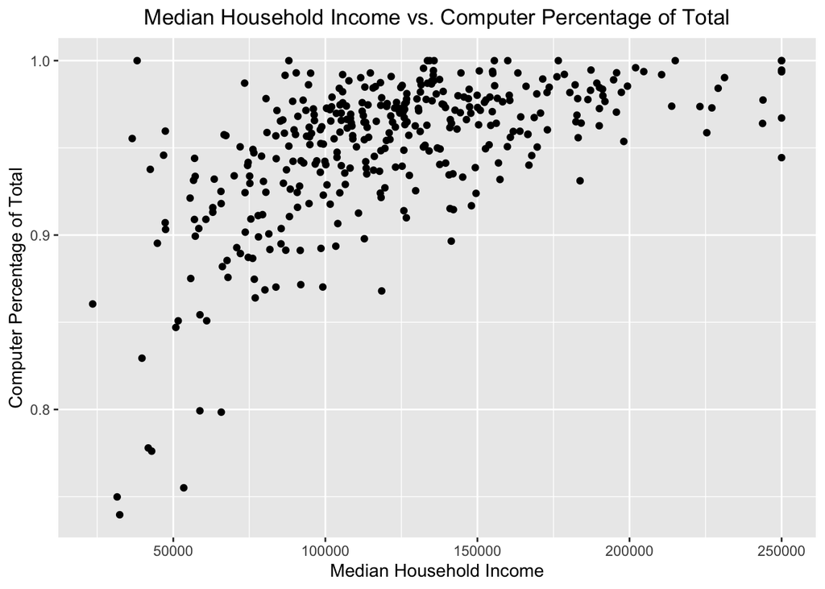

```r
# ScatterPlot of Computer Access v Income

# Data wrangling
computer_to_income <- techacesspercentage[c("computer_percentoftotal")]
computer_to_income["median_household_income"] <- householdincome["median_household_income"]

# Plotting the graph
ggplot(computer_to_income, aes(x = median_household_income, y = computer_percentoftotal)) +
  ggtitle("Median Household Income vs. Computer Percentage of Total") +
  theme(plot.title = element_text(hjust = 0.5)) +
  xlab("Median Household Income") +
  ylab("Computer Percentage of Total") +
  geom_point()
```

This program plots the median household income against the percentage of the households within each census tract with computer access in the form of a scatterplot. Each point represents a different census tract. Again, there are several points stacked vertically at $250,000 due to the way the data was stored.

Based on this visualization, we can again see that as the median household income increases, the percentage of the total population with access to computers increases. From this we can conclude that there is likely a relationship between income and access to computers in Santa Clara County: the richer an area is, the more likely everyone in the census tract has access to a computer in their home.

In addition, if we compare these two scatterplots, we see that more households have access to a computer than to the internet. For distance learning, this would still be a problem as distance learning requires an internet connection as well as a device.

#### Minority Population (percent) vs. Internet Access Visualization

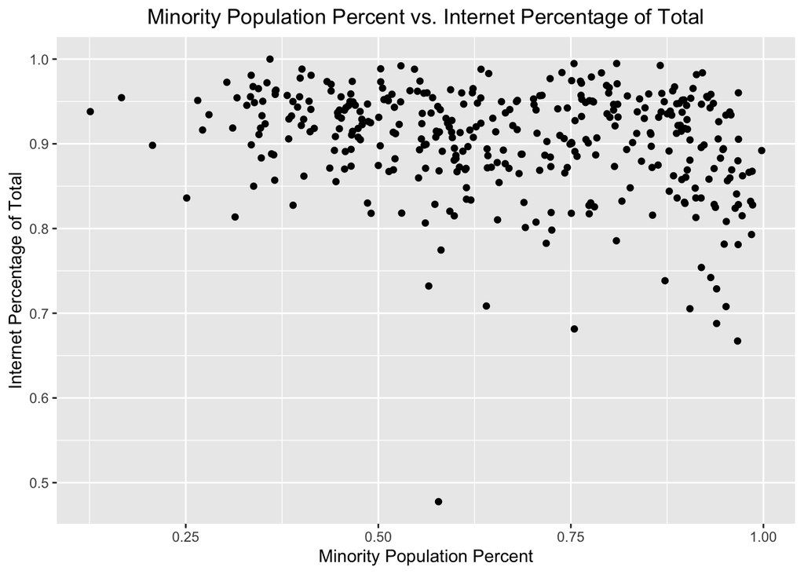

```r
# ScatterPlot of Internet Access v Minority Populations

# Data wrangling
internet_to_minority <- techacesspercentage[c("internet_percentoftotal")]

internet_to_minority$minority_percent <- as.numeric(demographicpercentage$`hispanic_latino_percentoftotal`)+as.numeric(demographicpercentage$`black_or_african_american_percentoftotal`)+as.numeric(demographicpercentage$`american_indian_and_alaska_native_percentoftotal`)+as.numeric(demographicpercentage$`asian_alone_percentoftotal`)+as.numeric(demographicpercentage$`native_hawaiian_and_other_pacific_islander_percentoftotal`)+as.numeric(demographicpercentage$`some_other_race_percentoftotal`)+as.numeric(demographicpercentage$`two_or_more_races_percentoftotal`)

# Plotting the graph
ggplot(internet_to_minority, aes(x = minority_percent, y = internet_percentoftotal)) +
  ggtitle("Minority Population Percent vs. Internet Percentage of Total") +
  theme(plot.title = element_text(hjust = 0.5)) +
  xlab("Minority Population Percent") +
  ylab("Internet Percentage of Total") +
  geom_point()
```

This program plots the percentage of the population that is a minority (defined as non-white racial/ethnic group) within each census tract to the percentage of the households within each census tract with internet access, in the form of a scatterplot. Each point represents a different census tract. There seems to be an outlier on this graph as well (x around 0.6, y around 0.5).

Based on this visualization, we see a downward trend on the scatterplot –– as the percentage of minorities within the population of a census tract increases, the percentage of households with internet access trends downwards, and is more spread out vertically compared to the left side of the graph. We can conclude that there is probably a relationship between the size of the minority population within a census tract as well as the number of households with internet access –– the greater the minority population is (as a percentage of the total population of the census tract), the less likely a household would have internet access.

#### Minority Population (percent) vs Computer Access Visualization

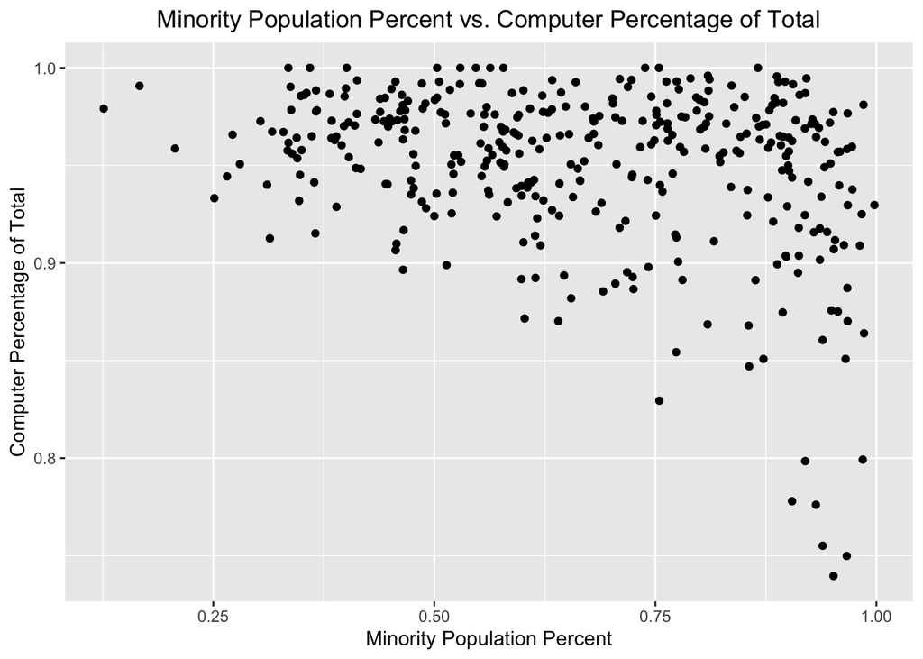

```r
# ScatterPlot of Computer Access v Minority Populations

# Data wrangling
internet_to_minority <- techacesspercentage[c("computer_percentoftotal")]

internet_to_minority$minority_percent <- as.numeric(demographicpercentage$`hispanic_latino_percentoftotal`)+as.numeric(demographicpercentage$`black_or_african_american_percentoftotal`)+as.numeric(demographicpercentage$`american_indian_and_alaska_native_percentoftotal`)+as.numeric(demographicpercentage$`asian_alone_percentoftotal`)+as.numeric(demographicpercentage$`native_hawaiian_and_other_pacific_islander_percentoftotal`)+as.numeric(demographicpercentage$`some_other_race_percentoftotal`)+as.numeric(demographicpercentage$`two_or_more_races_percentoftotal`)

# Plotting the graph
ggplot(internet_to_minority, aes(x = minority_percent, y = computer_percentoftotal)) +
  ggtitle("Minority Population Percent vs. Computer Percentage of Total") +
  theme(plot.title = element_text(hjust = 0.5)) +
  xlab("Minority Population Percent") +
  ylab("Computer Percentage of Total") +
  geom_point()
```

This program plots the percentage of the population that is a minority (defined as non-white racial/ethnic group) within each census tract to the percentage of the households within each census tract with computer access, in the form of a scatterplot. Each point represents a different census tract.

Based on this visualization, we also see a downward trend on the scatterplot –– as the percentage of minorities within the population of a census tract increases, the percentage of households with computer access trends downwards, and is more spread out vertically compared to the left side of the graph. We can conclude that there is probably a relationship between the size of the minority population within a census tract as well as the number of households with computer access –– the greater the minority population is (as a percentage of the total population of the census tract), the less likely a household would have computer access.

#### Median Household Income vs. Minority Population (percent) Visualization

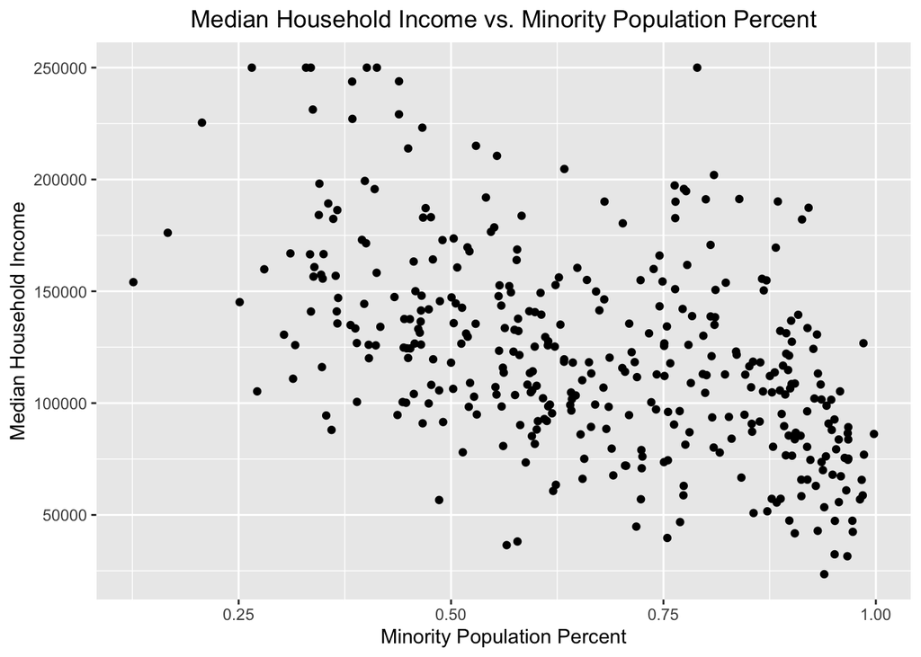

```r
#ScatterPlot of Income v Minority Populations

# Data wrangling
income_minority_populations <- householdincome[c("median_household_income")]

income_minority_populations$minority_percent <- as.numeric(demographicpercentage$`hispanic_latino_percentoftotal`)+as.numeric(demographicpercentage$`black_or_african_american_percentoftotal`)+as.numeric(demographicpercentage$`american_indian_and_alaska_native_percentoftotal`)+as.numeric(demographicpercentage$`asian_alone_percentoftotal`)+as.numeric(demographicpercentage$`native_hawaiian_and_other_pacific_islander_percentoftotal`)+as.numeric(demographicpercentage$`some_other_race_percentoftotal`)+as.numeric(demographicpercentage$`two_or_more_races_percentoftotal`)

# Plotting the graph
ggplot(income_minority_populations, aes(y = median_household_income, x = minority_percent)) +
  ggtitle("Median Household Income vs. Minority Population Percent") +
  theme(plot.title = element_text(hjust = 0.5)) +
  ylab("Median Household Income") +
  xlab("Minority Population Percent") +
  geom_point()
```

This program plots the percentage of the population that is a minority (defined as non-white racial/ethnic group) to the median household income within each census tract, in the form of a scatterplot. Each point represents a different census tract.

By looking at this plot, we see a pretty clear downward trend. As the percentage of minorities within a census tract increases, the median income decreases. Not only does this illustrate the income disparities between census tracts, but also the income inequality between minority-dominated census tracts and census tracts with a smaller minority population. This scatterplot shows that in Santa Clara County, communities of minorities and people of color are usually less well-off than communities with more white people, a trend we see outside of Santa Clara County as well.

Minority population and median income appear to be pretty closely linked, and based on the first two visualizations, we see median income and technology access also appear to be related. These last three graphs confirm these relationships by showing the relationship between minority population and technology access, as well as minority population and median income.

According to [The Mercury News](https://www.mercurynews.com/2018/06/25/the-eye-popping-definition-of-what-is-low-income-in-the-bay-area-increases-again/), a local news outlet in San Jose, a household is defined as low income if its income is under $94,450 a year, as of June 2018. We see that nearly all of the points underneath the horizontal line of $94,450 fall to the right of the 0.5 mark on the x-axis, meaning that nearly all census tracts where the household median income is below the definition of low income for a household (meaning more than half of all households within that census tract are low income) are comprised of more than 50% minorities. This analysis is further proof that the digital divide hits low-income communities and communities of color the hardest.

#### Computer Access vs. Internet Access Visualization

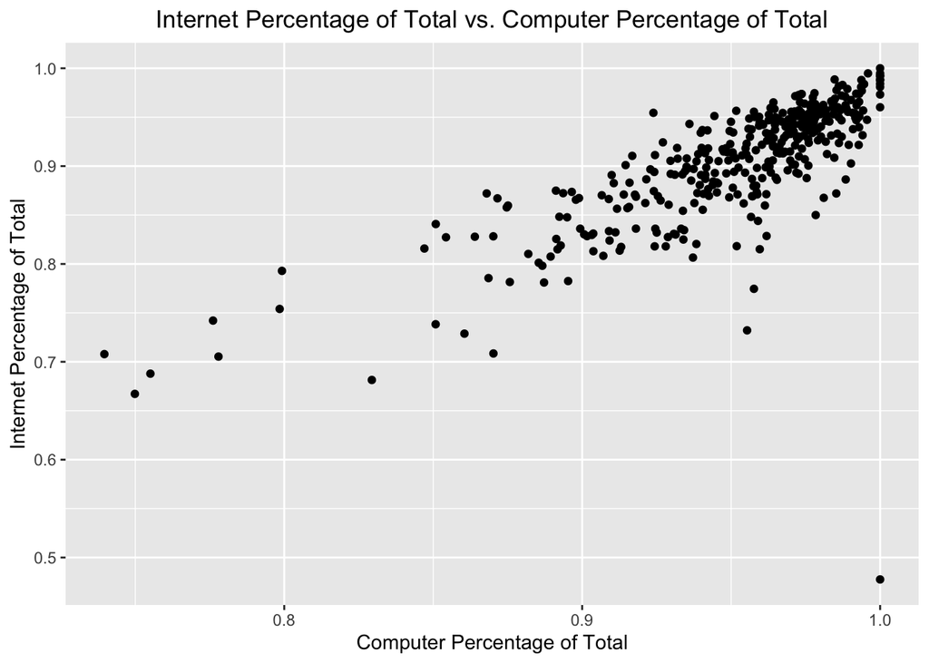

```r
#ScatterPlot of Computer Access v Internet Access

# Data wrangling
computer_to_internet <- techacesspercentage[c("computer_percentoftotal")]
computer_to_internet["internet_percentoftotal"] <- techacesspercentage["internet_percentoftotal"]

# Plotting the graph
ggplot(computer_to_internet, aes(x = computer_percentoftotal, y = internet_percentoftotal)) +
  ggtitle("Internet Percentage of Total vs. Computer Percentage of Total")+
  theme(plot.title = element_text(hjust = 0.5))+
  xlab("Computer Percentage of Total")+
  ylab("Internet Percentage of Total")+
  geom_point()
```

This program plots the percentage of the households with computer access to the percentage of households with internet access within a census tract. Each point represents a different census tract.

By this visualization, we see that census tracts with a higher percentage of computer access also have a higher percentage of internet access, meaning households with a computer also usually have access to the internet and vice versa.

#### Coronavirus Cases Visualization

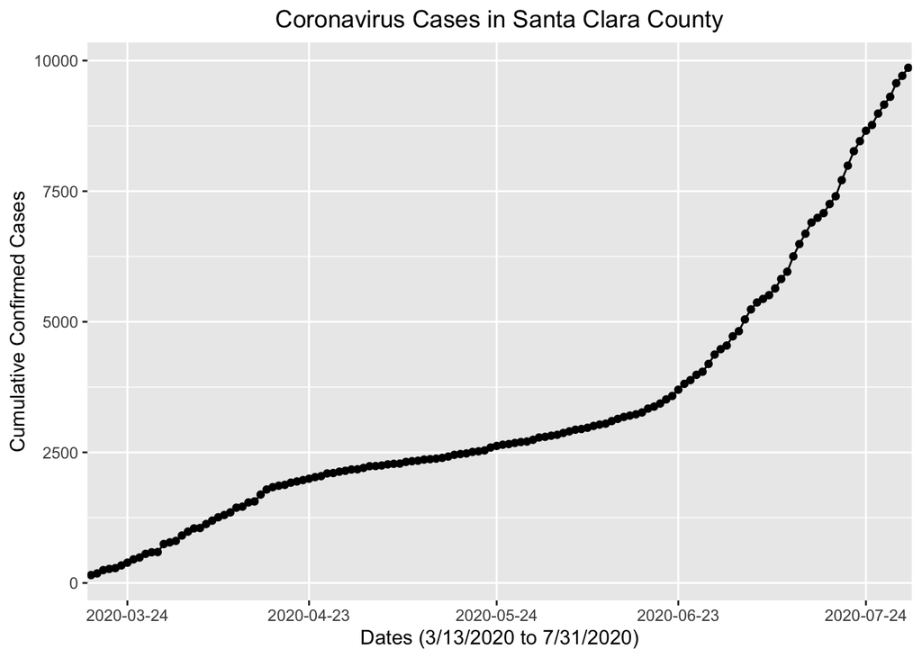

```r
# Creating a line graph to depict cumulative case count in Santa Clara County
ggplot(data=CoronaData, aes(x=date, y= totalcountconfirmed, group=1))+
  geom_line() +
  ggtitle("Coronavirus Cases in Santa Clara County") +
  theme(plot.title = element_text(hjust = 0.5)) +
  xlab("Dates (3/13/2020 to 7/31/2020)") +
  ylab("Cumulative Confirmed Cases") +
  scale_x_discrete(breaks =
    c("2020-03-24","2020-04-23","2020-05-24","2020-06-23","2020-07-24")) +
  geom_point()
```

Because the decision for schools to remain on distance learning (or come back to in-person/hybrid learning) largely depends on coronavirus cases, because the rate of cases being added to the cumulative count is increasing, distance learning will probably remain the implemented plan for a while, or at least in the fall. Thus, this graph shows that distance learning is here to stay, for now.

# Conclusion

### Summary of Results

In our analysis, we showed how household median income was linked to the levels of technology (computer and internet) access within census tracts: as median income went up, technology access levels (percent of households in a census tract with access to computer, internet) also trended upwards. We also showed the relationship between the size of the minority population as a percentage of the total and level of technology access within census tracts: as the minority population went up, technology access levels tended to trend downwards and spread out more. The most striking relationship we found was between the size of the minority population as a percentage of the total and household median income in a census tract: as the minority population (percentage) went up, household median income went down.

Based on this analysis, we can conclude that the digital divide in Santa Clara County is definitely not negligible, but not necessarily widespread. We also can conclude that the digital divide disproportionately affects communities of color and low-income communities, which also tend to be poorer than census tracts with a smaller minority population. Finally, we can also conclude that having a lower median income and/or higher minority population is related to having lower rates of technology access (percent of households in a census tract with access to a computer, and percent with access to the internet). Given the graph analysis of the coronavirus line graph, distance learning is likely here to stay in Santa Clara County, and several large school districts in Santa Clara County (such as the East Side Union High School District and San Jose Unified, which have a combined student population of over 55,000) have already begun their school year on distance learning, with no plans for hybrid/in-person learning in the fall.

### Broader Impact

In order to mitigate the impacts of the digital divide, action is needed to help the communities with low access to technology gain access. We’ve seen based on this analysis that those communities tend to be lower income, and have a higher percentage of the population as minorities. This means that policymakers and other organizations in Santa Clara County should target these groups with programs to help alleviate the digital divide. They can also use these visualizations to identify (to get the exact census tract name you need to go “under the hood” and look at the code) any other census tracts that may not fall under these categories but still have low access to technology.

For their credit, there are actually initiatives being taken to reduce the digital divide, especially in education. East Side Union High School District has launched a partnership with the City of San Jose, called the [Community Wireless Project](https://www.sanjoseca.gov/Home/Components/News/News/567/4960), bringing free internet to several communities within certain school boundaries. In addition, Dave Cortese, the District 3 Supervisor on the Santa Clara Board of Supervisors, has [launched programs to mitigate the digital divide](https://www.sccgov.org/sites/d3/covid-19/Documents/D3%20COVID-19%20Work.pdf) in a partnership with the Santa Clara County Office of Education. There have also been [partnerships with companies such as AT&T](https://www.mercurynews.com/2020/08/03/att-to-provide-11000-hotspots-to-san-jose-students-without-internet/) to bring hotspots to students.

However, there’s still a lot to be done to fully close the digital divide within Santa Clara County, as well as minimize the income disparities between communities of color and communities with a smaller percentage of minorities, though that may be beyond the scope of this project. We hope this project gives insight into some of the causes of the digital divide as well as the communities (and census tracts) that are most affected by the digital divide due to low rates of access to technology.

### Limitations

One of the biggest limitations of our project is the timeliness of the data –– because the most recent census data available was from 2018, and does not take into account recent developments (such as loss of work, Supervisor Dave Cortese’s digital divide campaign, school distribution of devices and hotspots, etc). In addition, we cannot make a prediction for a quantifiable estimate of how educational achievement will be affected, due to the lack of standardized testing data. In addition, we were unable to use GIS mapping software and shapefiles to create maps of the data, which would have made visualizing the disparities between census tracts much clearer than a scatterplot or any other visualization would. Also, the coronavirus data is at the county level, so we cannot use it to make predictions for each census tract and how each area will be affected based on the number of cases in a census tract. This prevents us from making a better analysis and conclusion from the census data we analyzed. We also don’t know how the coronavirus (and related job losses) have affected the demographics of the census tracts we analyzed, and the actual situation could be much worse than depicted in the visualizations.

### Deviations from Project Proposal

We actually ended up with quite a few deviations from the project proposal, mostly by not achieving the initial targets we had created for this project in the proposal. This was mostly due to time constraints and lack of data, as analyzing the Census data took much longer than anticipated, and doing any more would have taken an unreasonably large amount of time.

For broadband availability, we had planned on using public GIS data, but it was extremely difficult to navigate, understand, and download, even after seeking TA help. We also had trouble figuring out how to use the different files provided in a partial download we were able to find, such as using shapefiles and layers. However, we did anticipate potential problems with this data, so we specified that our backout plan would be to use the Census data, which we ended up using.

We had also originally planned on bringing in educational achievement as quantified by CAASPP Smarter Balanced scores (standardized test scores), but when we downloaded the tool and tried to access performance reports, we were only able to access individual school reports, and each of those were over 20 pages long. Seeing how there are hundreds of schools in Santa Clara County, we ended up abandoning educational achievement because it would be nearly impossible for us to export data for each school in a PDF, reformat it so we can use it in R, then wrangle/clean the data to remove the extraneous information.

Initially, the plan was to analyze zip codes in Santa Clara County, but we switched to census tracts for two reasons. First, the county webpage with the zip codes we bookmarked when preparing for the proposal stopped working, and required a password to login. We were unable to find a reliable source for a list of zip codes in the county elsewhere. Second, the Census data we were planning on using, after switching from the GIS data, could not be accessed by zip code. The smallest and most reasonable subdivision within the county we could download data from was by census tracts.

We also changed some of our visualization types due to the new data and the results of the data wrangling process (for example, no maps).

Ultimately, it came down to us not being able to carry out the ambitious plan we had set early on due to the problems described above (and then some), even after seeking teaching staff help, so we made some changes.

### Individual Contributions

We had meetings and discussed the project regularly, through Zoom and other messaging platforms to collaborate. Here is what each team member did:

Steven: Data Cleaning/Wrangling for Coronavirus data, Coronavirus data visualization, Census data visualizations, Report/explanation/analysis/presentation

Edward: Data Cleaning/Wrangling for Coronavirus data, Coronavirus data visualization, Census data visualizations, Report/explanation/analysis/presentation

We both spent a great deal of time on this project over the summer, and learned a lot about what’s going on around the county through analysis of Census data.